# chapter 2 exercises

## 2.6 Exercises

```r
library(raster)
```

### Exercise 1

> Use summary() on the geometry column of the world data object.

```r
summary(world)
```

```
    iso_a2           name_long          continent          region_un          subregion             type
 Length:177         Length:177         Length:177         Length:177         Length:177         Length:177
 Class :character   Class :character   Class :character   Class :character   Class :character   Class :character
 Mode  :character   Mode  :character   Mode  :character   Mode  :character   Mode  :character   Mode  :character




    area_km2             pop               lifeExp        gdpPercap                   geom
 Min.   :    2417   Min.   :5.630e+04   Min.   :50.62   Min.   :   597.1   MULTIPOLYGON :177
 1st Qu.:   46185   1st Qu.:3.755e+06   1st Qu.:64.96   1st Qu.:  3752.4   epsg:4326    :  0
 Median :  185004   Median :1.040e+07   Median :72.87   Median : 10734.1   +proj=long...:  0
 Mean   :  832558   Mean   :4.282e+07   Mean   :70.85   Mean   : 17106.0
 3rd Qu.:  621860   3rd Qu.:3.075e+07   3rd Qu.:76.78   3rd Qu.: 24232.7
 Max.   :17018507   Max.   :1.364e+09   Max.   :83.59   Max.   :120860.1
                    NA's   :10          NA's   :10      NA's   :17
```

> What does the output tell us about:
> - Its geometry type?

It’s a multipolygon, containing 177 polygons (presumably one for each country). I don’t understand the other two fields.

> - The number of countries?

177

> - Its coordinate reference system (CRS)?

### Exercise 2

> Run the code that ‘generated’ the map of the world in Figure 2.5 at the end of Section 2.2.4. Find two similarities and two differences between the image on your computer and that in the book.

```r
plot(world["continent"], reset = FALSE)
cex = (world$pop) / 100000000
world_cents = st_centroid(world, of_largest = TRUE)
```

```
st_centroid assumes attributes are constant over geometries of xst_centroid does not give correct centroids for longitude/latitude data
```

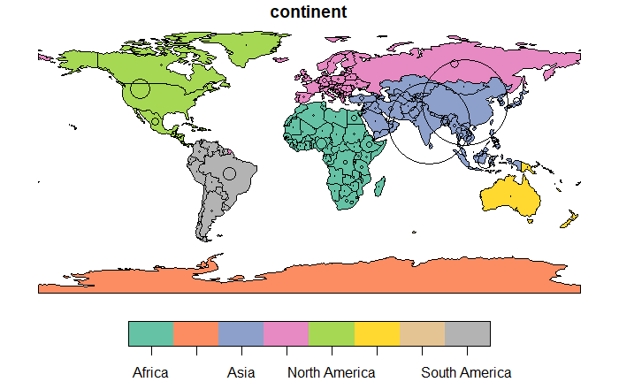

```r
plot(st_geometry(world_cents), add = TRUE, cex = cex, colour = )
```

> differences
- different projection
- includes a legend and a title
- symbols in different places and outline not bold
- no meridians

> similarities
- colours same

> What does the cex argument do (see ?plot)?

scales the plotting symbol by population

> Why was cex set to the sqrt(world$pop) / 10000?

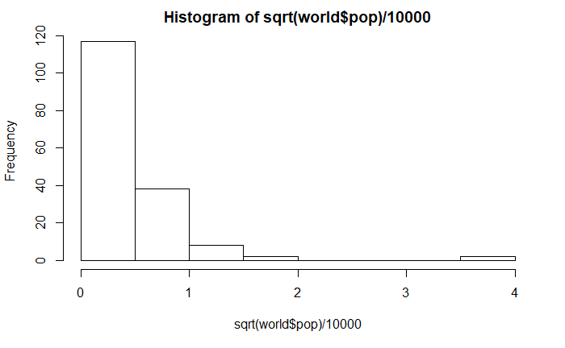

```r
hist(sqrt(world$pop) / 10000)
```

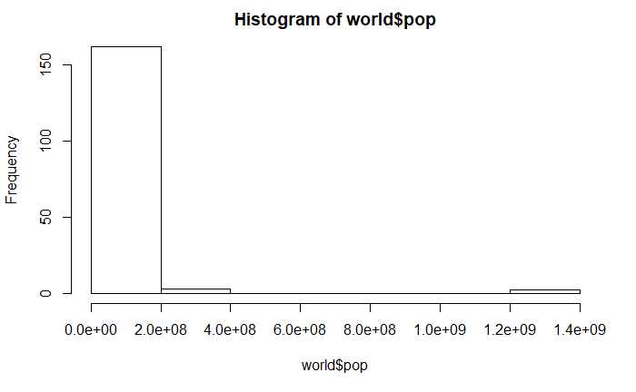

```r
hist(world$pop)
```

to constrain it to a reasonable scale for the cex parameter, and to avoid huge disparities (e.g. pop of India and China) although the caption is a bit misleading adn should have said that it’s proportional to the square root of the population.

> Bonus: experiment with different ways to visualize the global population.

```r
plot(world["continent"], reset = FALSE)
cex = (world$pop/max(world$pop, na.rm = T))*4
world_cents = st_centroid(world, of_largest = TRUE)
```

```
st_centroid assumes attributes are constant over geometries of xst_centroid does not give correct centroids for longitude/latitude data
```

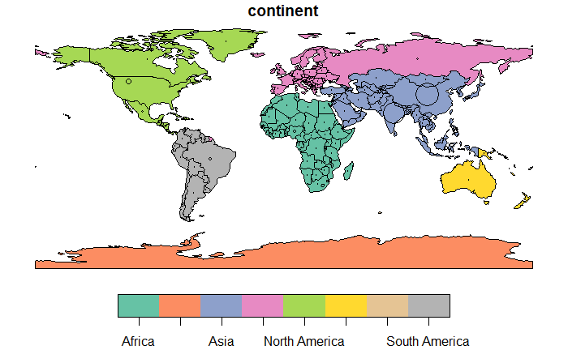

```r
plot(st_geometry(world_cents), add = TRUE, cex = cex)
```

> Use plot() to create maps of Nigeria in context (see Section 2.2.4). Adjust the lwd, col and expandBB arguments of plot(). Challenge: read the documentation of text() and annotate the map.

```r
nigeria <- world[which(world$name_long == "Nigeria"),]
plot(st_geometry(nigeria), expandBB = c(1.2, 0.5, 1.2, 0.5), lwd = 2)
plot(st_geometry(world), add = T)
```

[output not shown]

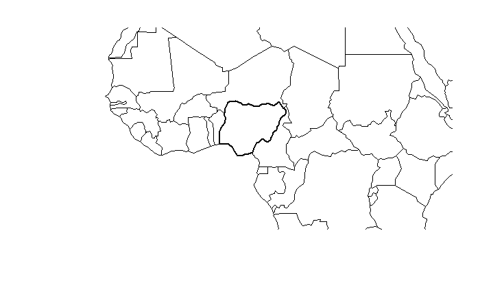

```r
text(world$name_long)
```

Create an empty RasterLayer object called my_raster with 10 columns and 10 rows. Assign random values between 0 and 10 to the new raster and plot it.

[figure not shown]

Read-in the raster/nlcd2011.tif file from the spDataLarge package. What kind of information can you get about the properties of this file?

```r
raster(system.file("raster/nlcd2011.tif", package = "spDataLarge"))
```

```
class      : RasterLayer
dimensions : 1359, 1073, 1458207  (nrow, ncol, ncell)
resolution : 31.5303, 31.52466  (x, y)
extent     : 301903.3, 335735.4, 4111244, 4154086  (xmin, xmax, ymin, ymax)
crs        : +proj=utm +zone=12 +ellps=GRS80 +towgs84=0,0,0,0,0,0,0 +units=m +no_defs
source     : C:/APPS/R/R-3.6.1/library/spDataLarge/raster/nlcd2011.tif
names      : nlcd2011
values     : 11, 95  (min, max)
```